# Ford GoBike System Data

## by Khalid Alqahtani

## Investigation Overview

- In this analysis, I would like to figure that when and where are most trips taken, and also i'm intrested in the biker if he's a Subscriber or a Customer.

## Dataset Overview

- This dataset includes 519,700 trips with 15 features such as locations, time, and user attributes. The dataset is subsetted by choosing top 8 trips start stations with the most trips due to the same stations with same amount of trips in the end stations. Also, June's data is removed because of lack of insufficient data in that month.

## Time of most trips

- most trips are in the afternoon then the morning
- most trips are in weekdays more than weekends
- trips increase from Jul to Oct and start to decrease in Nov and Dec

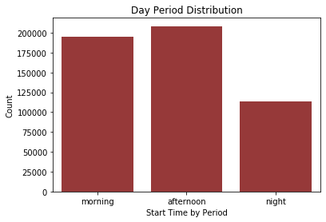

```python
sb.countplot(data=bike, x='period_day', color='brown')
plt.xlabel('Start Time by Period')
plt.ylabel('Count')
plt.title('Day Period Distribution');
```

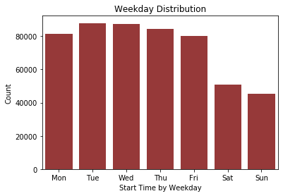

```python
sb.countplot(data=bike, x='start_weekday_char', color='brown')
plt.xlabel('Start Time by Weekday')
plt.ylabel('Count')
plt.title('Weekday Distribution');
```

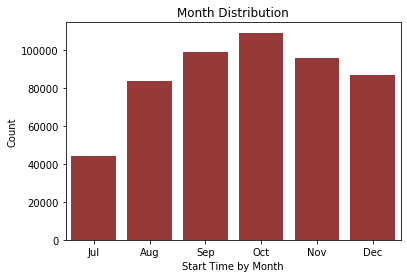

```python
sb.countplot(data=bike, x='start_month_char', color='brown')
plt.xlabel('Start Time by Month')
plt.ylabel('Count')
plt.title('Month Distribution');
```

## The top 8 stations with the most trips

- All of the start stations with the most trips are in San Francisco and connect to public transportations such as Caltrain, Bart and Ferry.

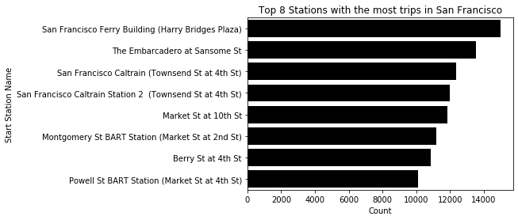

```python
ord = stations.start_station_name.value_counts().index
sb.countplot(data=stations, y='start_station_name', color='black', order=ord)
plt.xlabel('Count')
plt.ylabel('Start Station Name')
plt.title('Top 8 Stations with the most trips in San Francisco');
```

## The top 8 stations with the most trips by weekdays in each user type

- After separating user types, for customers, there are 6 out of 8 stations with the most trips in the weekend. Most of trips happen at Ferry Building and Embarcadero that are very popular tourist attractions. On the other hand, for subscribers, most of trips happen during the weekdays. Subscribers are more likely commuters.

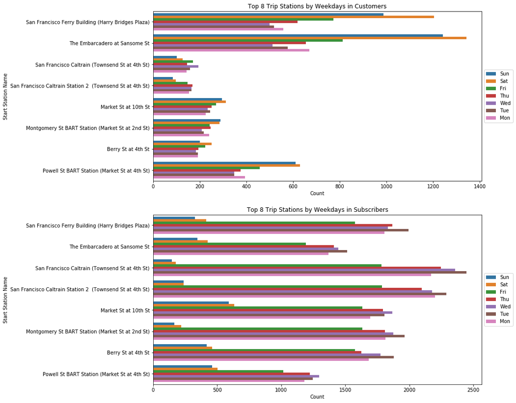

```python
plt.figure(figsize=(12,14))
ax = plt.subplot(211)
sb.countplot(data=stations.query('user_type == "Customer"'), y='start_station_name', hue='start_weekday_char', order=ord)
plt.legend(loc='center left', bbox_to_anchor=(1,0.5))
plt.title('Top 8 Trip Stations by Weekdays in Customers')
plt.xlabel('Count')
plt.ylabel('Start Station Name')

ax = plt.subplot(212)
sb.countplot(data=stations.query('user_type == "Subscriber"'), y='start_station_name', hue='start_weekday_char', order=ord)
plt.legend(loc='center left', bbox_to_anchor=(1,0.5))
plt.title('Top 8 Trip Stations by Weekdays in Subscribers')
plt.xlabel('Count')
plt.ylabel('Start Station Name');
```